# Landmark Analysis

version 1

Hyejung Lee hyejung.lee@utah.edu

Thu Apr 24, 2025 12:08:05 PM

# 1 Context

2025 April 14

I had a meeting with Tom and Ben on last Friday. Ben suggested that I restrict the patients to those who have:

- Survive at least 4 weeks post advanced diagnosis
- Have a valid test result by the end of the 4th week
- Have albumin, ECOG performance status, and weight change observed to use for analysis by the end of:
  - 1st week **(primary inclusion criteria)**
  - 4th week **(secondary inclusion criteria)**

The primary inclusion criteria addresses potential bias when baseline covariates are measured after treatment assignment. Note that treatment is a binary variable, which is a function of test result date and 1L therapy date.

Although our time zero is defined at week 5—implying that every patient must have at least one measurement of albumin, ECOG, and weight change—delayed covariate ascertainment risks adjusting for post‑baseline values. For example, if first‑line therapy begins in week 1 but albumin is first measured in week 3, that value may already reflect treatment effects. Restricting covariate observation to week 1 in the primary analysis (and comparing it to the week 4 window in the secondary analysis) helps approximate true baseline values at the time of advanced diagnosis.

# 2 Research Aims

- Aim 1) Identify causal effect of starting 1L therapy before receiving valid test results on overall survival of advanced non-small cell lung cancer patients.
- Aim 2) Identify the same thing as Aim 1 in the following subgroups of patients, which Wally had previously identified that they have higher/lower likelihood of targetable mutations: ECOG 0-2, ECOG 3-4, Albumin $\leq 35 g/L$, Albumin $> 35 g/L$, Asian, Female, Male, No history of smoking, History of smoking
- Aim 3) Investigate if there is a trend in causal effect of starting 1L therapy before receiving valid test results on overall survival based on the advanced diagnosis year

For all 3 aims, we will conduct analysis using the two different samples, each from the primary and secondary inclusion criteria.

# 3 Covariate

## 3.1 Time-fixed covariate

We will use Gender, race/ethnicity, time at advanced diagnosis, histology, smoking status, and age at diagnosis

## 3.2 Time-dependenet covariate

Baseline covariate ascertainment proceeded as follows, based on expert recommendations:

1. Covariates and time windows
   - **ECOG performance status**: any assessment recorded from 2 months before up to 1 week after (or 4 weeks after, for secondary inclusion criteria) the date of advanced diagnosis.
   - **Weight change (**$\geq 10$ lb loss): weight measurements from 6 months before up to 1 week after (or 4 weeks after, for secondary inclusion criteria) diagnosis, with at least two measurements in that interval.
   - **Serum albumin**: binary indicator ($\leq 35 g/L$ vs.$> 35 g/L$) from 6 weeks before up to 1 week after (or 4 weeks after, for secondary inclusion criteria) advanced diagnosis.
2. Inclusion criteria Patients were retained only if they had:
   - $\geq 1$ ECOG assessment in the specified window,
   - $\geq 2$ weight measurements in the specified window, and
   - $\geq 1$ albumin measurement in the specified window.
3. Value selection
   - ECOG and albumin: if measured on the date of advanced diagnosis, that value was used; otherwise, the measurement closest in time to diagnosis was selected, with preference for pre‑diagnosis values.
   - Weight change:
     - If $\geq 2$ measurements existed before diagnosis, we coded whether a $\geq 10$ lb loss occurred in the 6 months preceding diagnosis.
     - If fewer than two pre‑diagnosis measurements were available, we identified the earliest occurrence of $\geq 10$ lb loss within the period from 6 months pre‑diagnosis to 1 week (or 4 weeks, for secondary inclusion criteria) post‑diagnosis.

Implementation details are provided in the analysis script (new_setup_baseline_diagnosis_v3.R).

# 4 Exclusion

## 4.1 Primary Inclusion Criteria

| Exclusion | Number excluded | Number remaining |
| --- | --- | --- |
| Receive 1L therapy before advanced diagnosis date | 994 | 84207 |
| Receive valid test results before advanced diagnosis date | 6522 | 77685 |
| Died/censored before end of week 4 | 3215 | 74470 |
| Do not have any record of receiving valid test by the end of week 4 | 46764 | 27706 |
| Didn’t observe all variables (week 1) | 24690 | 3016 |

## 4.2 Secondary Inclusion Criteria

| Exclusion | Number excluded | Number remaining |
| --- | --- | --- |
| Receive 1L therapy before advanced diagnosis date | 994 | 84207 |
| Receive valid test results before advanced diagnosis date | 6522 | 77685 |
| Died/censored before end of week 4 | 3215 | 74470 |
| Do not have any record of receiving valid test by the end of week 4 | 46764 | 27706 |
| Didn’t observe all variables (week 4) | 16397 | 11309 |

# 5 Aim 1

## 5.1 Primary Analysis

### 5.1.1 Descriptive summary

Summary table:

(\#tab:tbl-primary-dscriptive)Table XX. Summary of patient characteristics at baseline, for data quality check purposes.

| **Characteristic** | **wait** N = 2,541<sup>1</sup> | **no_wait** N = 475<sup>1</sup> |
| --- | --- | --- |
| Albumin (<= 35 g/L vs. > 35g/L) |  |  |
| normal | 1,995 (79%) | 345 (73%) |
| low | 546 (21%) | 130 (27%) |
| Lost >= 10lbs | 65 (2.6%) | 11 (2.3%) |
| ECOG |  |  |
| Mean (SD) | 0.88 (0.81) | 0.86 (0.76) |
| Median (Q1, Q3) | 1.00 (0.00, 1.00) | 1.00 (0.00, 1.00) |
| SmokingStatus |  |  |
| History of smoking | 2,217 (87%) | 420 (88%) |
| No history of smoking | 324 (13%) | 55 (12%) |
| Histology |  |  |
| Non-squamous cell carcinoma | 1,865 (73%) | 331 (70%) |
| NSCLC histology NOS | 119 (4.7%) | 24 (5.1%) |
| Squamous cell carcinoma | 557 (22%) | 120 (25%) |
| Gender |  |  |
| F | 1,259 (50%) | 212 (45%) |
| M | 1,282 (50%) | 263 (55%) |
| Race/Ethnicity |  |  |
| AsianNonHisp | 56 (2.2%) | 16 (3.4%) |
| BlackNonHisp | 226 (8.9%) | 42 (8.8%) |
| HispLatino | 0 (0%) | 1 (0.2%) |
| Other | 716 (28%) | 152 (32%) |
| WhiteNonHisp | 1,543 (61%) | 264 (56%) |
| Approximate age at Advanced Diagnosis |  |  |
| Mean (SD) | 70 (10) | 67 (11) |
| Median (Q1, Q3) | 71 (63, 77) | 68 (61, 75) |
| Advanced Diagnosis (year) |  |  |
| Mean (SD) | 7.58 (2.39) | 7.07 (2.72) |
| Median (Q1, Q3) | 8.00 (6.00, 10.00) | 7.00 (5.00, 9.00) |

<sup>1</sup> n (%)

As we can observe in the table, there is only one person who is Hispanic/Latino in no wait cohort. This is insufficient data to make any meaningful analysis. Thus, we will fuse Hispanic Lanito to Other category for the analysis.

### 5.1.2 Inverse probability weight

Generate IPW, and re-construct the table.

| Variable | Level | No IPW Wait | No IPW No wait | No IPW SMD | IPW Wait | IPW No wait | IPW SMD |
| --- | --- | --- | --- | --- | --- | --- | --- |
| n |  | 2541.0 | 475.0 |  | 2540.8 | 476.9 |  |
| Albumin (<= 35 g/L vs. > 35g/L) (%) | normal | 1995.0 (78.5) | 345.0 (72.6) | 0.137 | 1971.2 (77.6) | 369.4 (77.5) | 0.003 |
|  | low | 546.0 (21.5) | 130.0 (27.4) |  | 569.5 (22.4) | 107.5 (22.5) |  |
| Lost >= 10lbs (%) | No | 2476.0 (97.4) | 464.0 (97.7) | 0.016 | 2476.9 (97.5) | 465.6 (97.6) | 0.009 |
|  | Yes | 65.0 ( 2.6) | 11.0 ( 2.3) |  | 63.9 ( 2.5) | 11.3 ( 2.4) |  |
| ECOG (mean (SD)) |  | 0.88 (0.81) | 0.86 (0.76) | 0.032 | 0.88 (0.81) | 0.88 (0.76) | 0.007 |
| SmokingStatus (%) | History of smoking | 2217.0 (87.2) | 420.0 (88.4) | 0.036 | 2222.0 (87.5) | 419.5 (88.0) | 0.015 |
|  | No history of smoking | 324.0 (12.8) | 55.0 (11.6) |  | 318.8 (12.5) | 57.4 (12.0) |  |
| Histology (%) | Non-squamous cell carcinoma | 1865.0 (73.4) | 331.0 (69.7) | 0.083 | 1849.8 (72.8) | 345.6 (72.5) | 0.009 |
|  | NSCLC histology NOS | 119.0 ( 4.7) | 24.0 ( 5.1) |  | 120.6 ( 4.7) | 23.4 ( 4.9) |  |
|  | Squamous cell carcinoma | 557.0 (21.9) | 120.0 (25.3) |  | 570.4 (22.4) | 107.9 (22.6) |  |
| Gender (%) | F | 1259.0 (49.5) | 212.0 (44.6) | 0.099 | 1240.1 (48.8) | 236.9 (49.7) | 0.017 |
|  | M | 1282.0 (50.5) | 263.0 (55.4) |  | 1300.7 (51.2) | 240.0 (50.3) |  |
| Race/Ethnicity (%) | AsianNonHisp | 56.0 ( 2.2) | 16.0 ( 3.4) | 0.122 | 60.5 ( 2.4) | 10.9 ( 2.3) | 0.020 |
|  | BlackNonHisp | 226.0 ( 8.9) | 42.0 ( 8.8) |  | 225.5 ( 8.9) | 40.0 ( 8.4) |  |
|  | Other | 716.0 (28.2) | 153.0 (32.2) |  | 732.6 (28.8) | 136.8 (28.7) |  |
|  | WhiteNonHisp | 1543.0 (60.7) | 264.0 (55.6) |  | 1522.2 (59.9) | 289.1 (60.6) |  |
| Approximate age at Advanced Diagnosis (mean (SD)) |  | 69.63 (9.71) | 67.48 (10.67) | 0.210 | 69.30 (9.82) | 69.51 (10.07) | 0.022 |
| Advanced Diagnosis (year) (mean (SD)) |  | 7.58 (2.39) | 7.07 (2.72) | 0.197 | 7.50 (2.42) | 7.53 (2.61) | 0.013 |

Based on the above table, we can observe that when we don’t apply IPW, the standardized mean difference (SMD) for albumin, race/ethnicity, age at diagnosis, and advanced diagnosis (year) were imbalanced (SMD > 0.1). However, after IPW, these covariates are all balanced (SMD < 0.1).

### 5.1.3 KM curve

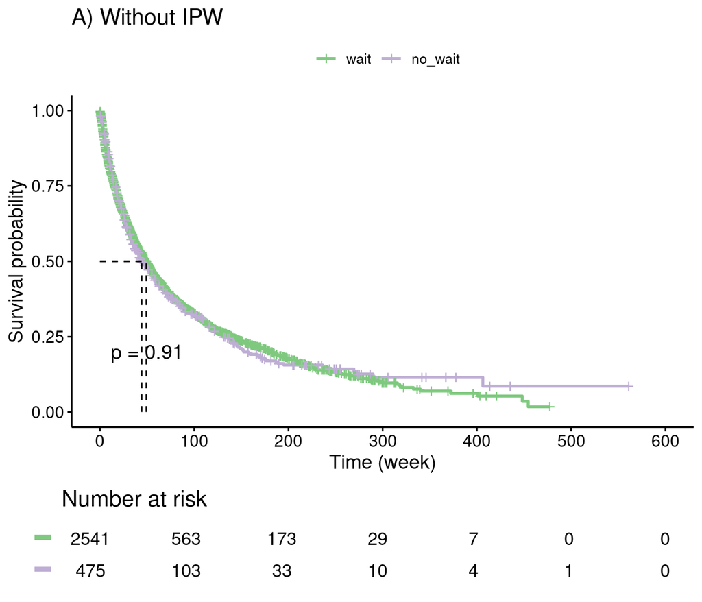

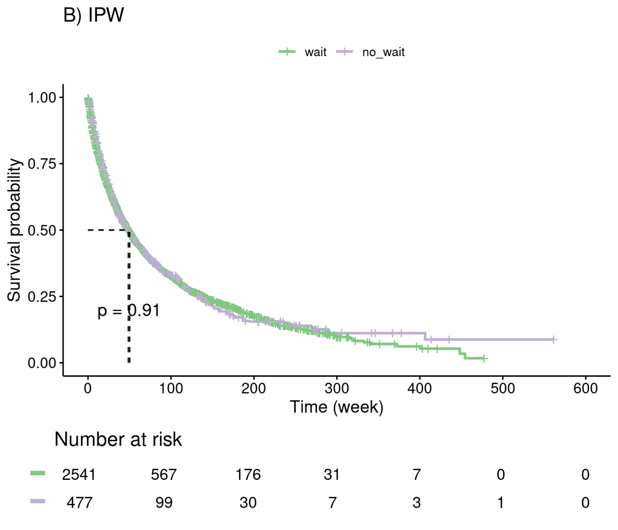

Figure 5.1: Figure XX. Kaplan-Meier (KM curve demonstrating survival probability over time. A) original data, B) IPW applied population.

### 5.1.4 Effect of 1L before test result become available

Using the IPW, we fitted a Cox PH model. The resulting hazard rate (95% confidence interval) of death by proceeding to 1L before receiving valid test result was 0.981 (0.869 - 1.106). Since the null value 1 is included in the 95% CI, we conclude that waiting or not waiting for valid test result proceeding to 1L did not cause much difference in survival.

Since the type of 1L therapy also affects survival, we show the 1L therapy distribution in the two IPW populations in the next subsection.

### 5.1.5 1L therapy distribution

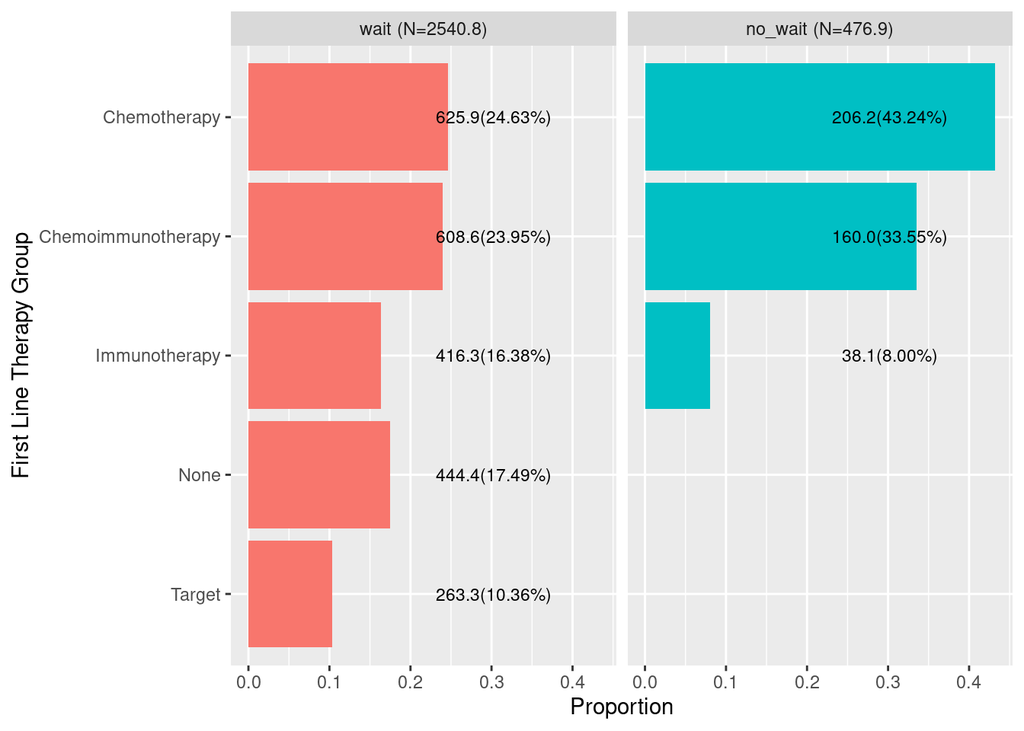

Figure 5.2: Figure XX Distribution of 1L therapy received by patients stratified by cohort with IPW applied. Only the treatments that compose more than 5% of either of the two cohorts is shown in the plot.

To check if targetable mutation patients really live longer or not, we generated IPW applied KM plot, comparing those who received targetable therapy versus not (whether they received anything or not). The variables used to generate IPW are the same as used in the main analysis.

With IPW, Histology, Gender, Race/Ethnicity, and Approximate age at Advanced Diagnosis reported slightly high SMD, ranging from 0.118 to 0.141. Since they don’t exceed 0.2, we will just use IPW population, assuming that covariance balanced was achieved. Below is KM plot of the IPW population. The median survival (95% CI) of those who received targetabl therapy was 113.43 (95%CI: 83.57 - 144.57), while those who didn’t were 44.86 (95%CI: 40.71 - 48.57).

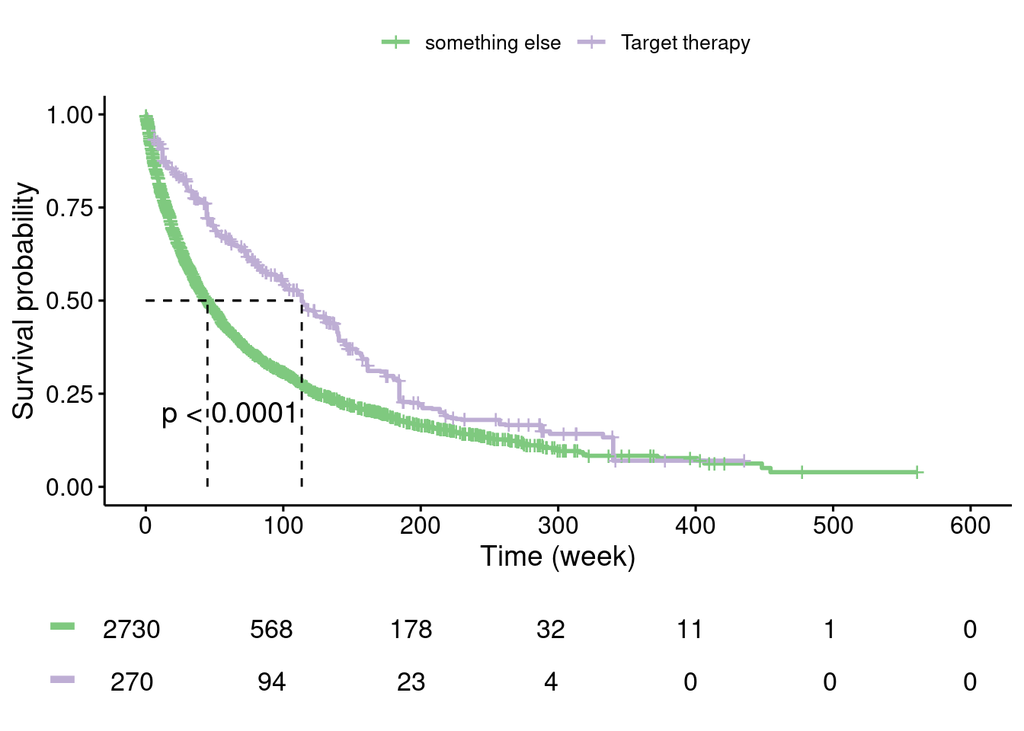

Figure 5.3: Figure XX KM received by patients stratified by 1L therapy. IPW population.

## 5.2 Secondary analysis

We repeat the primary analysis except with changed inclusion criteria, where the patients have up to 4 weeks after advanced diagnosis date to observe the baseline covariates.

### 5.2.1 Descriptive summary

Summary table:

(\#tab:tbl-secondary-dscriptive)Table XX. Summary of patient characteristics at baseline, for data quality check purposes.

| **Characteristic** | **wait** N = 9,890<sup>1</sup> | **no_wait** N = 1,419<sup>1</sup> |
| --- | --- | --- |
| Albumin (<= 35 g/L vs. > 35g/L) |  |  |
| normal | 6,688 (68%) | 854 (60%) |
| low | 3,202 (32%) | 565 (40%) |
| Lost >= 10lbs | 194 (2.0%) | 40 (2.8%) |
| ECOG |  |  |
| Mean (SD) | 0.96 (0.83) | 0.95 (0.82) |
| Median (Q1, Q3) | 1.00 (0.00, 1.00) | 1.00 (0.00, 1.00) |
| SmokingStatus |  |  |
| History of smoking | 8,410 (85%) | 1,231 (87%) |
| No history of smoking | 1,480 (15%) | 188 (13%) |
| Histology |  |  |
| Non-squamous cell carcinoma | 7,581 (77%) | 1,029 (73%) |
| NSCLC histology NOS | 430 (4.3%) | 70 (4.9%) |
| Squamous cell carcinoma | 1,879 (19%) | 320 (23%) |
| Gender |  |  |
| F | 4,831 (49%) | 653 (46%) |
| M | 5,059 (51%) | 766 (54%) |
| Race/Ethnicity |  |  |
| AsianNonHisp | 246 (2.5%) | 37 (2.6%) |
| BlackNonHisp | 821 (8.3%) | 91 (6.4%) |
| HispLatino | 7 (<0.1%) | 1 (<0.1%) |
| Other | 2,912 (29%) | 454 (32%) |
| WhiteNonHisp | 5,904 (60%) | 836 (59%) |
| Approximate age at Advanced Diagnosis |  |  |
| Mean (SD) | 68 (10) | 67 (10) |
| Median (Q1, Q3) | 69 (62, 76) | 68 (61, 75) |
| Advanced Diagnosis (year) |  |  |
| Mean (SD) | 7.49 (2.45) | 6.82 (2.78) |
| Median (Q1, Q3) | 8.00 (6.00, 9.00) | 7.00 (5.00, 9.00) |

<sup>1</sup> n (%)

As in the case if the primary analysis, there are hardly any Hispanic/Latino. Thus, they are combined with “Other” group.

### 5.2.2 Inverse probability weight

Generate IPW, and re-construct the table.

| Variable | Level | No IPW Wait | No IPW No wait | No IPW SMD | IPW Wait | IPW No wait | IPW SMD |
| --- | --- | --- | --- | --- | --- | --- | --- |
| n |  | 9890.0 | 1419.0 |  | 9890.1 | 1417.3 |  |
| Albumin (<= 35 g/L vs. > 35g/L) (%) | normal | 6688.0 (67.6) | 854.0 (60.2) | 0.155 | 6594.6 (66.7) | 937.1 (66.1) | 0.012 |
|  | low | 3202.0 (32.4) | 565.0 (39.8) |  | 3295.5 (33.3) | 480.2 (33.9) |  |
| Lost >= 10lbs (%) | No | 9696.0 (98.0) | 1379.0 (97.2) | 0.056 | 9685.0 (97.9) | 1385.8 (97.8) | 0.011 |
|  | Yes | 194.0 ( 2.0) | 40.0 ( 2.8) |  | 205.1 ( 2.1) | 31.6 ( 2.2) |  |
| ECOG (mean (SD)) |  | 0.96 (0.83) | 0.95 (0.82) | 0.005 | 0.96 (0.83) | 0.96 (0.82) | 0.002 |
| SmokingStatus (%) | History of smoking | 8410.0 (85.0) | 1231.0 (86.8) | 0.049 | 8432.4 (85.3) | 1217.8 (85.9) | 0.019 |
|  | No history of smoking | 1480.0 (15.0) | 188.0 (13.2) |  | 1457.7 (14.7) | 199.5 (14.1) |  |
| Histology (%) | Non-squamous cell carcinoma | 7581.0 (76.7) | 1029.0 (72.5) | 0.096 | 7529.7 (76.1) | 1077.8 (76.0) | 0.005 |
|  | NSCLC histology NOS | 430.0 ( 4.3) | 70.0 ( 4.9) |  | 437.3 ( 4.4) | 61.6 ( 4.3) |  |
|  | Squamous cell carcinoma | 1879.0 (19.0) | 320.0 (22.6) |  | 1923.2 (19.4) | 277.9 (19.6) |  |
| Gender (%) | F | 4831.0 (48.8) | 653.0 (46.0) | 0.057 | 4795.5 (48.5) | 686.1 (48.4) | 0.002 |
|  | M | 5059.0 (51.2) | 766.0 (54.0) |  | 5094.7 (51.5) | 731.3 (51.6) |  |
| Race/Ethnicity (%) | AsianNonHisp | 246.0 ( 2.5) | 37.0 ( 2.6) | 0.084 | 247.3 ( 2.5) | 34.0 ( 2.4) | 0.012 |
|  | BlackNonHisp | 821.0 ( 8.3) | 91.0 ( 6.4) |  | 797.2 ( 8.1) | 111.1 ( 7.8) |  |
|  | Other | 2919.0 (29.5) | 455.0 (32.1) |  | 2951.5 (29.8) | 427.8 (30.2) |  |
|  | WhiteNonHisp | 5904.0 (59.7) | 836.0 (58.9) |  | 5894.0 (59.6) | 844.4 (59.6) |  |
| Approximate age at Advanced Diagnosis (mean (SD)) |  | 68.38 (10.18) | 67.38 (10.16) | 0.099 | 68.26 (10.21) | 68.29 (9.83) | 0.003 |
| Advanced Diagnosis (year) (mean (SD)) |  | 7.49 (2.45) | 6.82 (2.78) | 0.253 | 7.40 (2.48) | 7.42 (2.65) | 0.006 |

### 5.2.3 KM curve

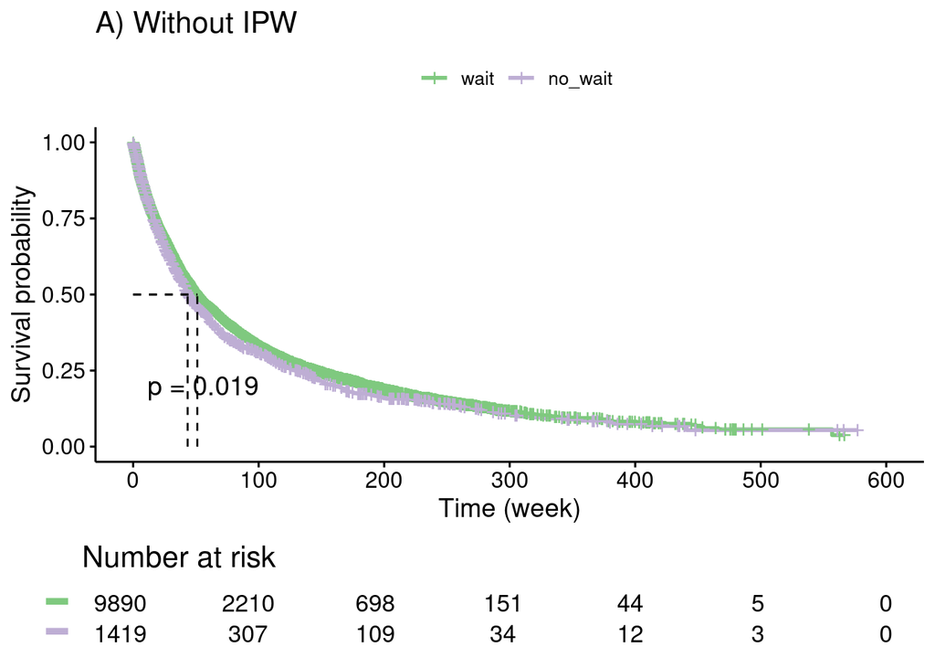

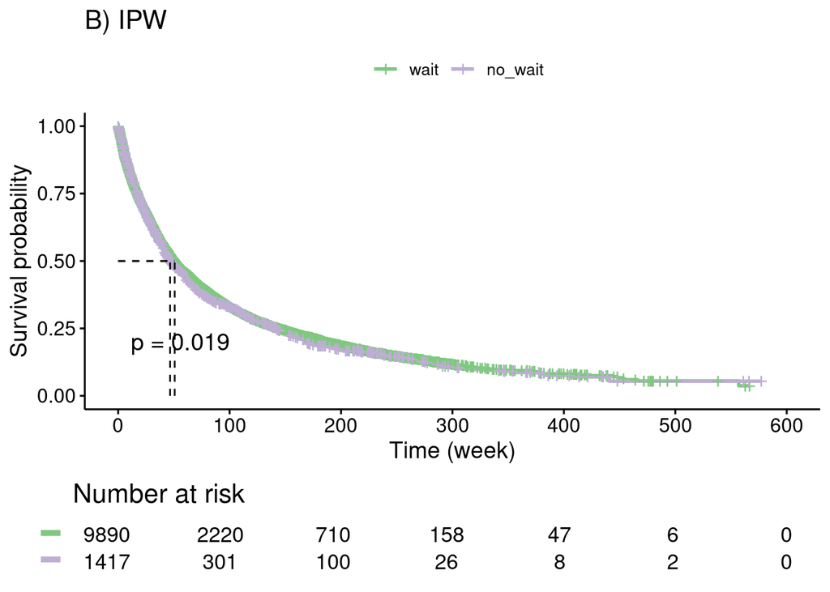

Figure 5.4: Figure XX. Kaplan-Meier (KM curve demonstrating survival probability over time. A) original data, B) IPW applied population.

Without IPW, the median survival of “wait” and “no wait” cohorts were 51.14 (95%CI: 49.14 - 53.43), and 43.43 (95%CI: 41.00 - 47.86), respectively. Patients who waited lived substantially longer.With IPW, however, the median survival decreased slightly in wait cohort (50.71 (95%CI: 48.57 - 52.86)), and increased quite a bit in no wait cohort (46.57 (95%CI: 42.43 - 52.86)). Therefore, the difference in the median survival between the two cohorts is attenuated with IPW.

### 5.2.4 Effect of 1L before test result become available

Since the type of 1L therapy also affects survival, we show the 1L therapy distribution in the two IPW populations in the next subsection.

### 5.2.5 1L therapy distribution

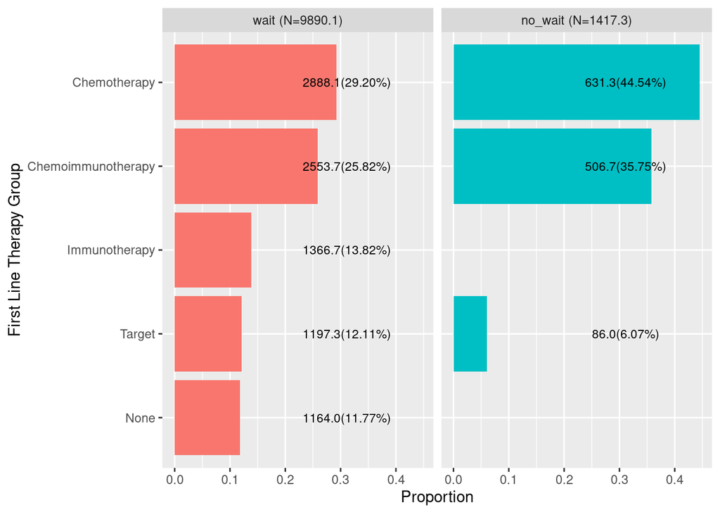

Figure 5.5: Figure XX Distribution of 1L therapy received by patients stratified by cohort with IPW applied. Only the treatments that compose more than 5% of either of the two cohorts is shown in the plot.

Just like the primary analysis, the most common therapies were chemotherapy, followed by chemo-immunotherapy for both cohorts. However, we observed target therapy from small number of patients in the “no-wait” cohort. This could just be data issue, where some people got tested and found out targetable mutation, but the data did not capture that. For “wait” cohort, the third most common therapy was immunotherapy.

# 6 Aim 2

As in the case with the Aim 1, the Hispanic/Latino patients were combined with the Other group.

# 7 Aim 3

Treatment availability differed substantially over time, reflecting rapid advances in therapies for targetable mutations over the past decade. Therefore, we stratified our analysis by calendar year (2011–2022). We used the same confounders used in Aim 1 to construct IPW.

When applying the primary inclusion criteria, either positivity assumption violation or large SMD was observed, rendering causal inference infeasible. In contrast, the data defined by the secondary inclusion criteria demonstrated no positivity violations or covariate imbalance from 2014 onward. Accordingly, we present below the causal estimates for 2014–2022, based on the secondary‐criteria dataset.

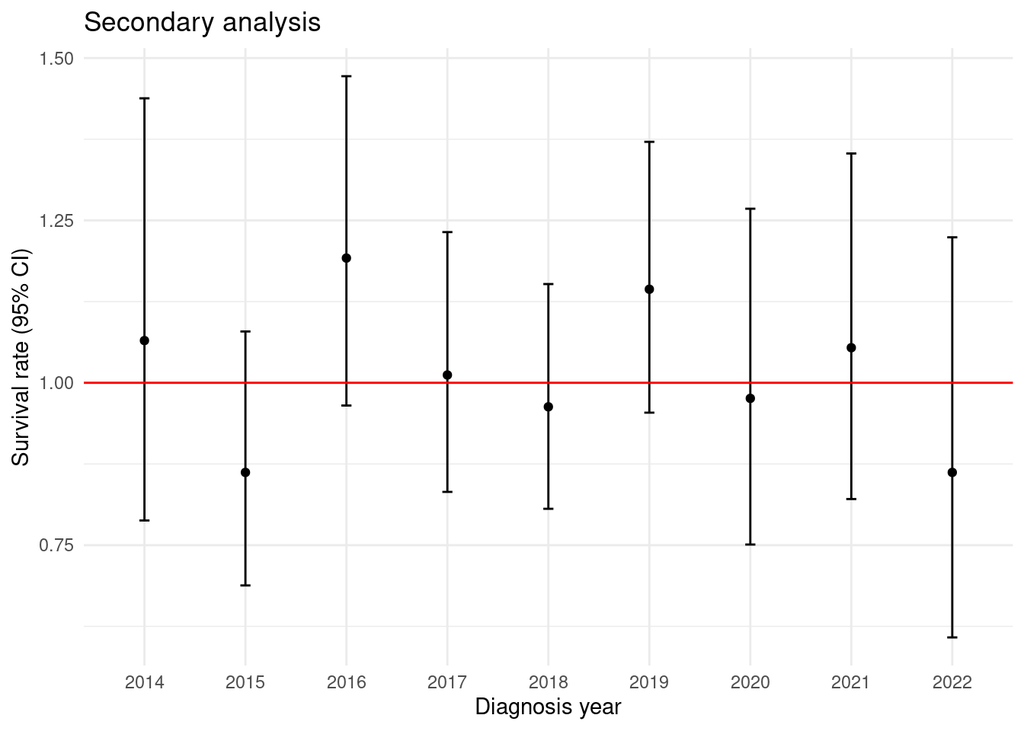

(#fig:fig-subgroup-by_year-secondary)Figure XX. HR(95%CI) of those who don’t wait for valie test result prior to initiating 1L therapy, grouped by advanced diagnosis year. Samples were collected using secondary inclusion criteria.

As we can see in the plot above, there isn’t much trend in hazard ratio.